# 폐경 전 여성에서 비만 표현형에 따른 요골동맥 맥파의 운동 반응

Radial Artery Pulse Wave Response to Sub-maximal Walking in Healthy Women with Obesity Phenotypes

2026-07-02

## 배경

같은 BMI라도 지방의 분포 위치(상체 또는 하체)에 따라 심혈관 위험이 다르게 나타남.

Android

Apple type, 상체(복부·내장) 지방

[figure not shown]

높은 WHR, 대사·심혈관 위험이 높은 편

Gynoid

Pear type, 하체(둔부·대퇴) 지방

[figure not shown]

낮은 WHR, 상대적으로 위험이 낮은 편

- 안정 시 측정만으로는 두 표현형의 혈관 기능 차이가 잘 드러나지 않을 수 있음
- 운동 부하 후 요골 맥파 특징과 심박변이도(HRV)를 동시에 관찰

## 연구 질문과 가설

**질문:** 보행운동 자극 후 요골 맥파·자율신경 반응이 비만 표현형(Android vs Gynoid)에 따라 다르게 나타날까?

- Android: 자율신경·혈류역학 반응성이 둔화
- Gynoid: 중추 자율신경(교감/부교감 신경) 반응은 정상에 가깝고, 말초 반응은 표현형 고유 패턴 존재 가능
- 지방 분포와 무관하게 과체중으로 인한 공통 효과 존재

탐색적 임상연구: 연구 결과를 바탕으로 새로운 가설 생성 가능 확인

## 연구 설계

- 관찰적 표현형 군간 비교(비무작위) + 운동 전/후 반복측정 (혼합설계 / mixed design)
- IRB WKIRB-2015/8, 2015년 9~12월 등록, 광주/전남
- 폐경 전 여성, 20~45세

**Control** (n = 13)  
18.5 ≤ BMI < 23.0 kg/m²

**Gynoid** (n = 14)  
BMI ≥ 25.0 & WHR < 0.85

**Android** (n = 15)  
BMI ≥ 25.0 & WHR ≥ 0.90

표현형 대비를 뚜렷하게 하려고 WHR 0.85~0.90 구간은 의도적으로 제외

## 대상자 선정 및 분석 세트

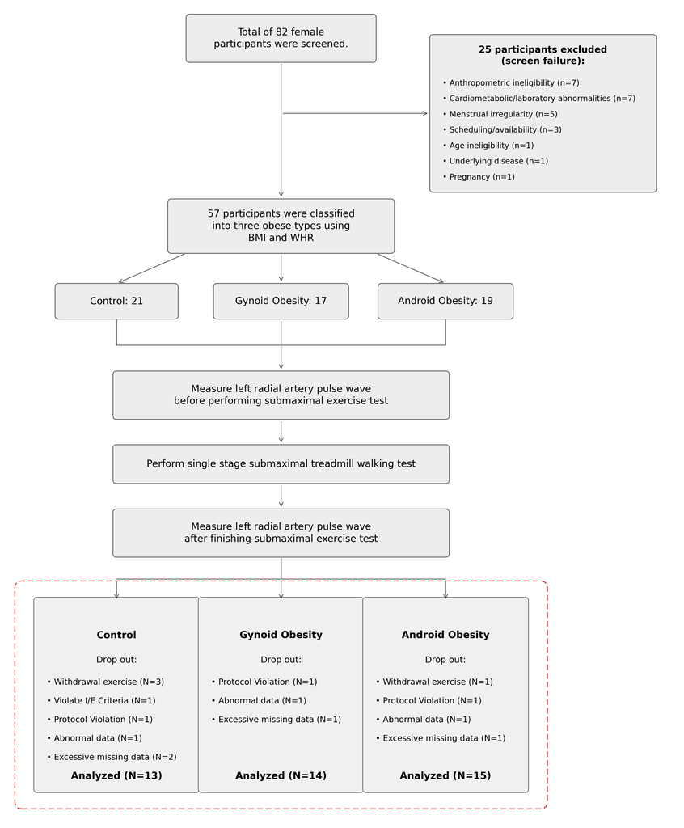

**Participants Flows**  
82 → 57 → 42명

Final Analysis Set: **42명**

Control 13 / Gynoid 14 / Android 15

## 대상자 특성

두 비만군은 **총 지방량(BMI)이 유사**(27.0 vs 27.8, 두 비만군 간 p = 0.71). BMI 전체 p < 0.001은 정상군(21.0)과의 차이에서 기인하며, **지방 분포(WHR·WC)는 뚜렷이 달라** 표현형 대비에 적합

| 변수 | Control | Gynoid | Android | 전체 p | 두 비만군 간 |
| --- | --- | --- | --- | --- | --- |
| 연령·키·안정 시 BP·맥박·생활습관 | 유사 | 유사 | 유사 | > 0.08 | — |
| BMI (kg/m²) | 21.0 ± 1.4 | 27.0 ± 1.9 | 27.8 ± 3.9 | < 0.001 | 0.71 |
| 허리둘레 WC (cm) | 72.6 ± 5.9 | 83.6 ± 6.6 | 96.0 ± 8.8 | < 0.001 | < 0.001 |
| WHR | 0.76 ± 0.05 | 0.80 ± 0.04 | 0.93 ± 0.03 | < 0.001 | < 0.001 |

- **총 지방량은 유사**: BMI·체중·엉덩이둘레 모두 두 비만군 간 유의차 없음 (Android vs Gynoid p = 0.71 / 0.73 / 0.88)
- **지방 분포는 다름**: WHR·허리둘레는 두 비만군 간에도 유의하게 차이 (모두 p < 0.001)
- 전체 p값(3군 ANOVA)은 정상군과 두 비만군의 차이를 크게 반영

## 운동 부하 프로토콜 (single-stage sub-maximal treadmill walking test, SSTWT)

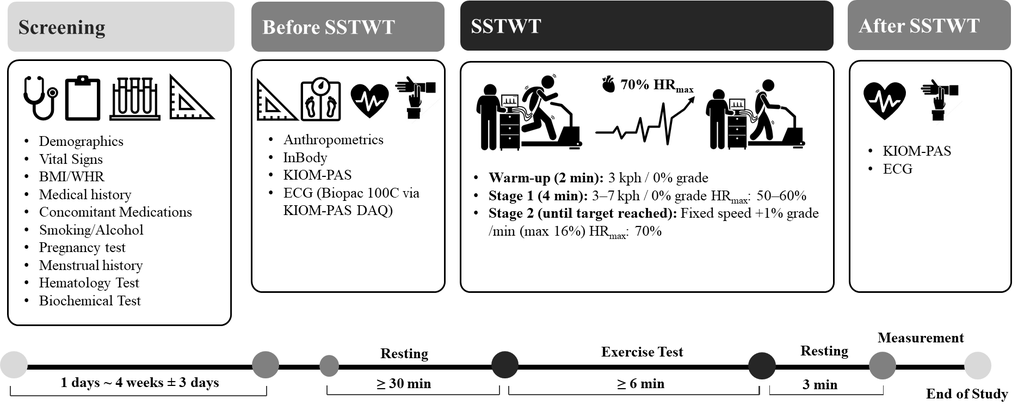

- **방식**: 단일 단계 준최대 트레드밀 보행 (Ebbeling 프로토콜)
- **목표 강도**: 연령 예측 **HRmax = 211 − 0.64 × age** (Nes)
- **진행**: 준비 2분(3 kph·0%) → 1단계 4분(0%·3~7 kph·50~60% HRmax) → 2단계 경사 1%/분↑(최대 16%) → **70% HRmax** 도달
- **측정**: 운동 직전, 종료 3분 후(early recovery)

## 측정 장비와 결과 변수

**장비:** KIOM-PAS ver 2.0 압맥파 측정기 (6채널 압저항 센서, 1000 Hz, Butterworth 0.005~30 Hz), 심전도 동시 측정 Biopac ECG100C (3-lead) → HRV

**결과 변수 (3개 도메인, 총 25개 지표)**

**① HRV (심박변이도, 자율신경 지표)**

- NN: 평균 NN 간격
- SDNN: NN 간격 표준편차
- RMSSD: 연속 차이의 RMS
- nLF/nHF: 정규화 저/고주파 파워 (0.04~0.15 / 0.15~0.4 Hz)
- LF/HF: 저·고주파 파워 비

**② 맥파형 특징** (맥파 구성파의 시점 T·높이 H)

- 충격파: T1·H1, H1w 충격파 높이 2/3 지점의 폭
- 조석파: T3·H3
- 절흔: T4·H4 (incisura)
- 중복파: T5·H5
- rAIx@75: 75 bpm 표준화 요골 augmented index

**③ 맥파 분석지수**

- PPI: 최대 맥파 도달 시 센서 전압
- PDI: 피부면 수직 방향 센서 변위 (맥파 깊이)
- OAP: 맥파 진폭이 최대가 되는 최적 가압
- PTI20~90: 최대 맥파점과 최대 진폭의 p% 초과 시작점 사이 변위

## 결과 변수 특징

① HRV 심박변이도

시간영역 (time domain), NN 간격

[figure not shown]

NN, SDNN, RMSSD

주파수영역 (frequency domain), LF/HF

[figure not shown]

nLF, nHF, LF/HF

요골 맥파 radial pulse

② 맥파형 특징, 구성파 시점·높이

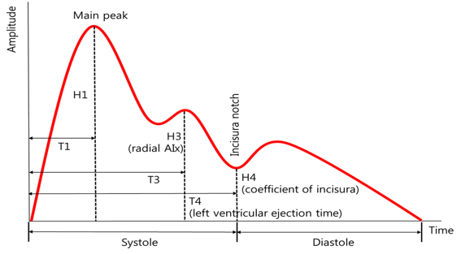

H1 충격파, H3 rAIx, H4 절흔(incisura)

③ 맥파 분석지수, 가압–변위 곡선

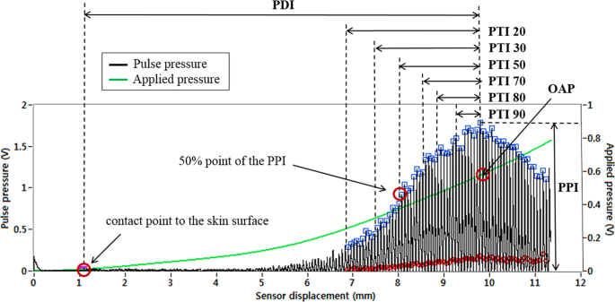

PPI, PDI, OAP, PTI20~90

## 통계 분석

$$\text{outcome}_{ij} = \beta_0 + \beta_1 \text{stage} + \beta_2 \text{group} + \beta_3(\text{stage}\times\text{group}) + \beta_4 \text{baseline} + u_i + \varepsilon_{ij}$$

- 선형혼합효과모형(LME): baseline을 공변량으로, 참가자를 random intercept($u_i$)로
- 핵심 검정: stage × group interaction (F-test, **p<sub>int</sub>**)
- 군간차 보고 (주 지표): **변화량 차이(MD), 95% CI, p-value**
  - 효과크기(**Cohen’s d**): (within [전/후 변화량], between [군간 변화량 차이])
- 사후 대비: Tukey HSD 보정

**핵심 검정: stage × group interaction (p<sub>int</sub>)**

**25개 지표에 대한 다중비교는 보정하지 않음**

## 운동 후 자율신경 반응: Android 둔화

interaction non-significant nLF p<sub>int</sub> = 0.068 (경계)

- Control·Gynoid: 운동 후 정상 sympathovagal shift (nLF↑, nHF↓, LF/HF↑; 모두 p ≤ 0.003)
- Android: 주파수 영역 변화 없음 (모두 p > 0.21)
- 운동 후 Android nLF가 유의하게 낮음
  - Android vs. Control: MD −13.3% (95% CI −24.2, −2.4), p = 0.013, 효과크기 d = −0.69
  - Android vs. Gynoid: MD −11.9% (95% CI −22.3, −1.6), p = 0.020, 효과크기 d = −0.65
- NN·RMSSD는 세 군 공통 감소 (p < 0.001), between 차이 없음

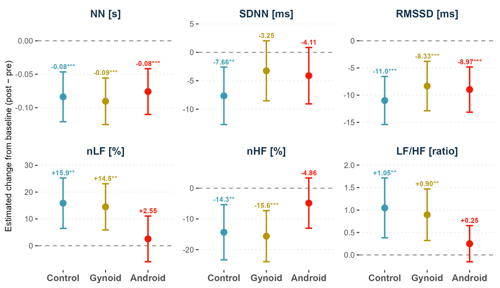

고찰

- Android의 주파수 영역 무반응 → 자율신경 반응성 저하(blunted sympathovagal shift) 시사. interaction non-significant, 재현 필요.
- nLF은 교감·미주 성분 혼재로 두 기전 구분 불가(해석 주의). 방향성은 복부지방·자율신경 선행연구와 부합(Grassi 2015; Farah 2013).
- PTI 연계: Control PTI 상승(심박출량↑) vs Android PTI 감소 → cardiovascular reactivity 결손 가능성.

## H4: 두 비만군 공통 감소, Control은 변화 없음

interaction significant H4 = 절흔 높이 (incisura height), p<sub>int</sub> = 0.002

**Gynoid**: −6.87%, p < 0.001, 효과크기 d = −0.53

**Android**: −4.33%, p = 0.006, 효과크기 d = −0.34

**Control**: +1.03%, p = 0.525 (non-significant)

운동 후 군간차 (변화량 차이 MD)

- Gynoid vs. Control: MD −7.90% (95% CI −11.7, −4.1), p < 0.001, 효과크기 d = −1.17
- Android vs. Control: MD −5.36% (95% CI −9.2, −1.5), p = 0.004, 효과크기 d = −0.79

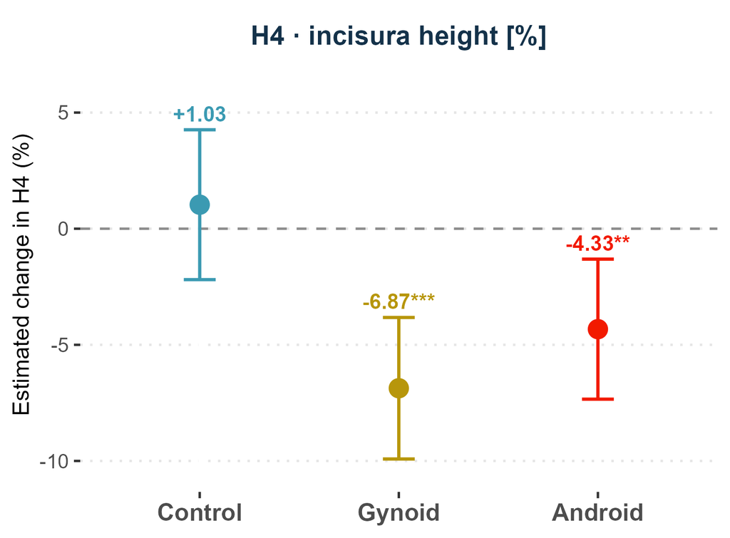

고찰

- 두 비만군 공통 감소, Control 변화 없음 → 지방 분포와 무관한 과체중의 공통 효과(파형 전달 특성 변화).
- H4(절흔 높이) 감소는 운동 후 반사파 특성(크기·시점) 변화를 반영. 안정 시엔 드러나지 않던 차이가 운동 부하로 표면화.

## rAIx@75와 H4의 dissociation: 비율 지표의 한계

interaction non-significant rAIx@75: p<sub>int</sub> = 0.470, H4: p<sub>int</sub> = 0.002로 → 두 반사 지표가 Android에서 엇갈림

**정의와 관찰**

$$\text{rAIx@75} = H3\,/\,H1$$

H3 = 반사파(조석파), H1 = 충격파(forward wave)

rAIx@75 within-group 변화:

- Gynoid −11.8% (p = 0.018, significant)
- Android −8.18% (p = 0.087, 경계)
- Control 변화 없음 (p = 0.547)

**기전: 분모(H1)가 분자(H3) 변화를 상쇄**

**Gynoid**: H1 ↑ (+0.17 V), H3 ↓ (−8.27%) → 분자↓·분모↑ → 비율 뚜렷이 감소

**Android**: H1 ↓ (−0.19 V, 심박출 증강 둔화), H3 ↓ (−4.12%) → 분모(H1) 감소가 H3 감소 상쇄 → 비율 변화 가려짐

**한계**

- rAIx@75(= H3/H1): 반사파(H3)·forward wave(H1) 변화를 한 값에 섞은 비율 지표
- H1 동반 변동 시(운동·교감신경 변화) H3 변화의 상쇄 → 위음성(false negative) 소지
- 절대 지표 H4(절흔 높이): H1 교란에 둔감, 반사 변화(크기·시점) 직접 반영
- 비율 지표(AIx)의 보완 수단: 절대 파형 지표 병용

## PTI: 압력 임계값별 방향성

압력 임계값(PTI20~90)에서 운동 후 방향은 일관되나, interaction 유의성은 낮은 임계값에서만 확인됨.

**운동 후 방향** (within-group, 모든 임계값 일관)

- Control 증가 (+)
- Android 감소 (−)
- Gynoid 미미

**Interaction 유의성**

- significant PTI20 / PTI30
- non-significant PTI50~90 (p<sub>int</sub> > 0.15)

**운동 후 군간차** (Android < Control, 탐색적)

| 임계값 | MD, mm (95% CI) | p | 효과크기 d |
| --- | --- | --- | --- |
| PTI50 | −0.22 (−0.42, −0.02) | 0.026 | −0.62 |
| PTI70 | −0.18 (−0.35, −0.02) | 0.023 | −0.63 |
| PTI90 | −0.11 (−0.22, 0.00) | 0.047 | −0.56 |

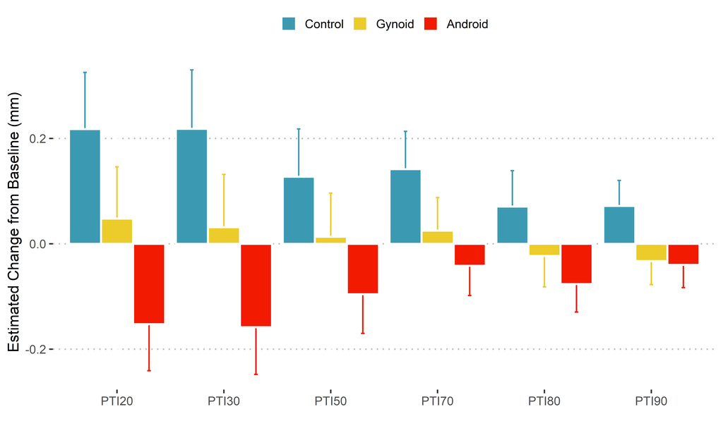

## PTI20 / PTI30: Control은 증가, Android는 감소

interaction significant **PTI20**: p<sub>int</sub> = 0.032, **PTI30**: p<sub>int</sub> = 0.034

운동 후 Control 증가 vs. Android 감소 (방향 반대), Gynoid는 미미

| 지표 | Control ↑ | Android ↓ | Android−Control MD (95% CI) |
| --- | --- | --- | --- |
| **PTI20** | +0.22 | −0.15 | −0.37 (−0.61, −0.13) |
| **PTI30** | +0.22 | −0.16 | −0.38 (−0.62, −0.13) |

- 변화량 단위: mm
- 군간차 모두 **p = 0.001** (PTI20, PTI30)
- 효과크기 d = −0.86 / −0.85

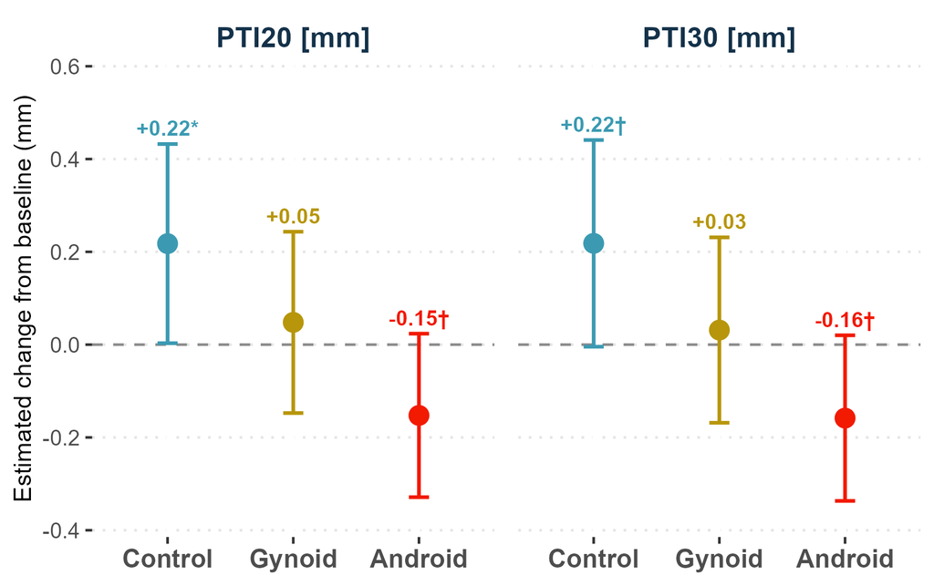

**고찰:** 낮은 압력 임계값에서 Android의 맥파 박동성이 Control과 **반대 방향으로 감소** → 운동 자극에 대한 **중추(자율신경) 조절 반응이 둔해진 것**으로 해석.

## PDI: Gynoid에서만 유의하게 증가

interaction significant PDI = pulse depth index, p<sub>int</sub> = 0.049

- 운동 후 Gynoid만 PDI 증가
- Control·Android는 변화 없음

| 군 | 운동 후 변화 | vs Control: MD (95% CI) |
| --- | --- | --- |
| **Gynoid** | +0.73 mm | +0.94 (0.27, 1.61) |
| Control, Android | 변화 없음 (p > 0.41) | — |

- Gynoid within·between 모두 **p = 0.004**
- 효과크기 d: within 0.75, between 0.84

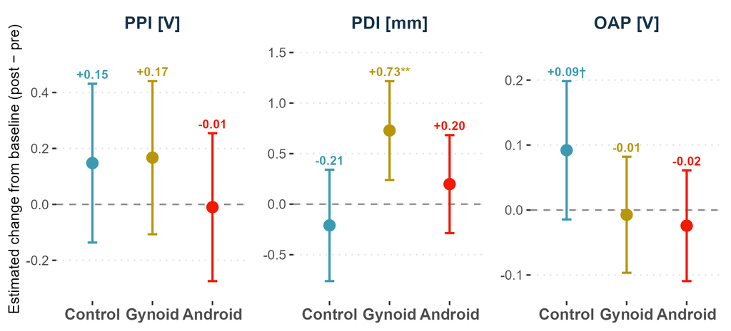

**고찰:** Gynoid에서만 나타난 말초 변화 → 운동으로 유발되는 **말초 혈관 확장(vasodilation) 능력이 유지**됨을 시사.

## PPI와 OAP

interaction non-significant 표현형 구분 기여는 제한적

| 지표 | interaction p<sub>int</sub> | 요약 |
| --- | --- | --- |
| **PPI** | 0.598 (non-significant) | interaction도 변화도 유의하지 않음 (모두 p > 0.22) |
| **OAP** | 0.254 (non-significant) | 운동 후 Android vs. Control 차이 경계, MD −0.12 (95% CI −0.24, 0.01), p = 0.071, 효과크기 d = −0.52 |

두 지표는 표현형 구분에 크게 기여하지 않음

## 통합 해석: Android vs Gynoid vs 공통

| 도메인 | Control | Gynoid | Android | 해석 |
| --- | --- | --- | --- | --- |
| 자율신경 (HRV) | 정상 이동 | 정상 이동 | 무반응 | Android 중추 자율신경 반응성 둔화 non-significant |
| 맥파 박동성 (PTI20/30) | 증가 | 무변화 | 감소 | Android 박동성 저하 significant |
| 심박출 증강 (H1 방향) | 증가 | 증가 (+0.17 V) | 감소 (−0.19 V) | Android 증강 약화 non-significant |
| 반사파 (H3, 조석파) | 무변화 | 감소 (−8.27%) | 감소 (−4.12%) | 두 비만군 반사파 감소 (rAIx@75 해리와 연결) non-significant |
| 말초 형태 (PDI·rAIx@75) | 무변화 | PDI +0.73 mm, rAIx@75 −11.8% | 미미 | Gynoid 말초 vasodilation 유지 (PDI significant) |
| 파형 전달 (H4) | 무변화 | −6.87% | −4.33% | 두 비만군 공통 감소 significant |

- Android: 자율신경 둔화 + 박동성 감소 + 심박출 증강 약화 → 내장지방에 부합하는 중추 매개 반응성 결핍
- Gynoid: 중추 자율신경 정상 + 증강 유지 + 말초 변화 고유 → 운동 유발 말초 vasodilation 능력 유지
- 공통(두 비만군, Control엔 없음): H4 감소 → 지방 분포와 무관한 과체중의 효과

## 한계

- 표본이 작음 (N = 42, 군당 13~15명) → 검정력 제한
- 표현형 군이 무작위 배정이 아닌 관찰적 분류 → 인과관계 규명은 제한적
- WHR 기반 분류 + 0.85~0.90 제외 구간 → 일반화 제한
- 내장/피하 지방을 직접 영상으로 측정하지 않음
- 운동 후 단일 시점(약 3분, early recovery)만 측정
- 난포기 시점을 생화학적으로 확인하지 않음
- 요골 측정치가 중심 대동맥 혈류역학으로 그대로 확장되지 않을 수 있음
- 25개 지표에 대한 다중비교 보정 없음

## 결론

운동 부하는 안정 시 드러나지 않는 비만 **표현형별 혈류역학 반응 차이**를 드러낸다

**Findings** significant

- **H4 감소**(두 비만군 공통) → 지방 분포와 무관한 과체중 효과
- **PTI20 / PTI30**: Control 증가 vs Android 감소 → Android 맥파 박동성 저하
- **PDI 증가**(Gynoid 고유) → 운동 유발 말초 vasodilation 유지

**표현형별 반응**

- Android(내장지방형): 박동성 저하 + 중추 자율신경 반응 둔화 **경향**
- Gynoid(둔부지방형): 중추 반응 정상 + 말초 vasodilation **유지**